# Crimes in Chicago - A Predictive Approach

Milestone 2 - Data Analysis I

By Rushiraj Nenuji,Nischitha Krishna, Chandan Ramanna, Santhosh Kumar Ravindran and Yin Yang

March 5, 2017

# Introduction

Crime in Chicago has been tracked by the Chicago Police Department’s Bureau of Records since the beginning of the 20th century. The city’s overall crime rate, especially the violent crime rate, is substantially higher than the US average. Chicago was responsible for nearly half of 2016’s increase in homicides in the US, though national crime rates stayed near historic lows. As of 2017, Chicago’s homicide rate is significantly higher when compared to the larger American cities of New York and Los Angeles.

Keeping these concerns in mind, we have leveraged the dataset to analyse and perform prediction on crime events (except the murder cases) that occurred in the City of Chicago from 2001 to present. The data resource is from Chicago Police Department’s CLEAR (Citizen Law Enforcement Analysis and Reporting) system. For our project, We have 6280886 millions of the data records. It will include 22 variables, such as

“ID” “Case.Number” “Date” “Block” “IUCR” “Primary.Type” “Description” “Location.Description” “Arrest” “Domestic” “Beat” “District” “Ward” “Community.Area” “FBI.Code” “X.Coordinate” “Y.Coordinate” “Year” “Updated.On” “Latitude” Longitude" “Location”

In order to protect the privacy of crime victims, addresses are shown at the block level only and specific locations are not identified. The list of crime even events are

“THEFT” “BATTERY”  
“ROBBERY” “CRIMINAL DAMAGE”  
“DECEPTIVE PRACTICE” “NARCOTICS”  
“ASSAULT” “OTHER OFFENSE”  
“CRIMINAL TRESPASS” “GAMBLING”  
“ARSON” “BURGLARY”  
“PROSTITUTION” “MOTOR VEHICLE THEFT”  
“WEAPONS VIOLATION” “HOMICIDE”  
“OFFENSE INVOLVING CHILDREN” “CRIM SEXUAL ASSAULT”  
“SEX OFFENSE” “LIQUOR LAW VIOLATION”  
“INTERFERENCE WITH PUBLIC OFFICER” “KIDNAPPING”  
“PUBLIC PEACE VIOLATION” “INTIMIDATION”  
“STALKING” “PUBLIC INDECENCY”  
“RITUALISM” “OTHER NARCOTIC VIOLATION”  
“OBSCENITY” “NON-CRIMINAL”  
“CONCEALED CARRY LICENSE VIOLATION” “HUMAN TRAFFICKING”  
“NON-CRIMINAL (SUBJECT SPECIFIED)” “NON - CRIMINAL”  
“DOMESTIC VIOLENCE”

We wanted to delve deeper into this statistic, properly detect outliers and deal with missing values in our dataset. Using 10 professional graphs to analysis the dataset. and using predictive analytics to solve some classification and prediction problems on our dataset. And solving some question:

# Data Source and Collection

. The data set for analyzing Chicago crimes is obtained from City of Chicago official site.

. The City of Chicago’s Data Portal is dedicated to promoting access to government data and encouraging the development of creative tools to engage and serve Chicago’s diverse community. The site hosts over 200 datasets presented in easy-to-use formats about City departments, services, facilities and performance.

. Below is the link which redirects to the above mentioned site.

https://data.cityofchicago.org/Public-Safety/Crimes-2001-to-present/ijzp-q8t2

# Data Set Manipulation

## Cleaning up the environment by removing all the elements in env

```r
rm(list = ls())
```

## We require to load these packages before we start generating graphs

```r
library(ggmap)
```

```r
library(ggplot2)
library(magrittr)
library(dplyr)
library(plotly)
```

## Importing the Data set csv file into R environment using read.csv and creating a data frame.

```r
crimedf <- read.csv(file = "Crimes_in_Chicago.csv", stringsAsFactors = FALSE)
df5 <- read.csv(file = "Last5Years.csv", stringsAsFactors = FALSE)
crime.data <- read.csv(file = "CrimesCleansed.csv", stringsAsFactors = FALSE)
```

## Structure of the Data set

```r
str(crimedf)
```

```
## 'data.frame':    6280886 obs. of  22 variables:
##  $ ID                  : int  7403616 7403617 7403618 7403619 7403620 7403621 7403622 7403623 7403624 7403625 ...
##  $ Case.Number         : chr  "HS183887" "HS205577" "HS205661" "HS186418" ...
##  $ Date                : chr  "02/27/2010 04:32:43 PM" "03/13/2010 10:40:00 AM" "03/13/2010 11:30:00 AM" "03/01/2010 02:45:00 PM" ...
##  $ Block               : chr  "044XX W VAN BUREN ST" "042XX W JACKSON BLVD" "049XX W 50TH ST" "007XX S CALIFORNIA AVE" ...
##  $ IUCR                : chr  "2027" "1811" "1320" "2027" ...
##  $ Primary.Type        : chr  "NARCOTICS" "NARCOTICS" "CRIMINAL DAMAGE" "NARCOTICS" ...
##  $ Description         : chr  "POSS: CRACK" "POSS: CANNABIS 30GMS OR LESS" "TO VEHICLE" "POSS: CRACK" ...
##  $ Location.Description: chr  "VACANT LOT/LAND" "RESIDENTIAL YARD (FRONT/BACK)" "STREET" "ALLEY" ...
##  $ Arrest              : chr  "true" "true" "false" "true" ...
##  $ Domestic            : chr  "false" "false" "false" "false" ...
##  $ Beat                : int  1131 1132 814 1135 714 1112 715 734 734 211 ...
##  $ District            : int  11 11 8 11 7 11 7 7 7 2 ...
##  $ Ward                : int  24 28 23 2 15 27 15 17 17 2 ...
##  $ Community.Area      : int  26 26 56 27 67 23 67 67 67 35 ...
##  $ FBI.Code            : chr  "18" "18" "14" "18" ...
##  $ X.Coordinate        : int  1146809 1148134 1144050 1157815 1164703 1150254 1163639 1169553 1167539 1179099 ...
##  $ Y.Coordinate        : int  1897653 1898348 1871018 1896728 1865370 1904756 1867866 1857531 1857320 1881485 ...
##  $ Year                : int  2010 2010 2010 2010 2010 2010 2010 2010 2010 2010 ...
##  $ Updated.On          : chr  "02/04/2016 06:33:39 AM" "02/04/2016 06:33:39 AM" "02/04/2016 06:33:39 AM" "02/04/2016 06:33:39 AM" ...
##  $ Latitude            : num  41.9 41.9 41.8 41.9 41.8 ...
##  $ Longitude           : num  -87.7 -87.7 -87.7 -87.7 -87.7 ...
##  $ Location            : chr  "(41.87513113, -87.736444941)" "(41.877012903, -87.731562139)" "(41.80209312, -87.74724229)" "(41.872375703, -87.696060374)" ...
```

## Summary of the Data set

```r
summary(crimedf)
```

```
##        ID           Case.Number            Date
##  Min.   :     634   Length:6280886     Length:6280886
##  1st Qu.: 3281552   Class :character   Class :character
##  Median : 5814494   Mode  :character   Mode  :character
##  Mean   : 5858041
##  3rd Qu.: 8296998
##  Max.   :10866882
##
##     Block               IUCR           Primary.Type
##  Length:6280886     Length:6280886     Length:6280886
##  Class :character   Class :character   Class :character
##  Mode  :character   Mode  :character   Mode  :character
##
##
##
##
##  Description        Location.Description    Arrest
##  Length:6280886     Length:6280886       Length:6280886
##  Class :character   Class :character     Class :character
##  Mode  :character   Mode  :character     Mode  :character
##
##
##
##
##    Domestic              Beat         District          Ward
##  Length:6280886     Min.   : 111   Min.   : 1.00   Min.   : 1.0
##  Class :character   1st Qu.: 623   1st Qu.: 6.00   1st Qu.:10.0
##  Mode  :character   Median :1111   Median :10.00   Median :22.0
##                     Mean   :1196   Mean   :11.31   Mean   :22.6
##                     3rd Qu.:1732   3rd Qu.:17.00   3rd Qu.:34.0
##                     Max.   :2535   Max.   :31.00   Max.   :50.0
##                                    NA's   :49      NA's   :614861
##  Community.Area     FBI.Code          X.Coordinate      Y.Coordinate
##  Min.   : 0.0     Length:6280886     Min.   :      0   Min.   :      0
##  1st Qu.:23.0     Class :character   1st Qu.:1152907   1st Qu.:1859146
##  Median :32.0     Mode  :character   Median :1165918   Median :1890250
##  Mean   :37.7                        Mean   :1164473   Mean   :1885639
##  3rd Qu.:58.0                        3rd Qu.:1176342   3rd Qu.:1909357
##  Max.   :77.0                        Max.   :1205119   Max.   :1951622
##  NA's   :616047                      NA's   :74685     NA's   :74685
##       Year       Updated.On           Latitude       Longitude
##  Min.   :2001   Length:6280886     Min.   :36.62   Min.   :-91.69
##  1st Qu.:2004   Class :character   1st Qu.:41.77   1st Qu.:-87.71
##  Median :2007   Mode  :character   Median :41.85   Median :-87.67
##  Mean   :2008                      Mean   :41.84   Mean   :-87.67
##  3rd Qu.:2011                      3rd Qu.:41.91   3rd Qu.:-87.63
##  Max.   :2017                      Max.   :42.02   Max.   :-87.52
##                                    NA's   :74685   NA's   :74685
##    Location
##  Length:6280886
##  Class :character
##  Mode  :character
##
##
##
##
```

## Clean the DATA-SET, removing missing data

```r
nacrimedf <- na.omit(crimedf)
```

## Plotting 10 Graphs

## Graph 1. Trend line depicting Number of Crimes per year (2001 to Present) (Crime versus Year)

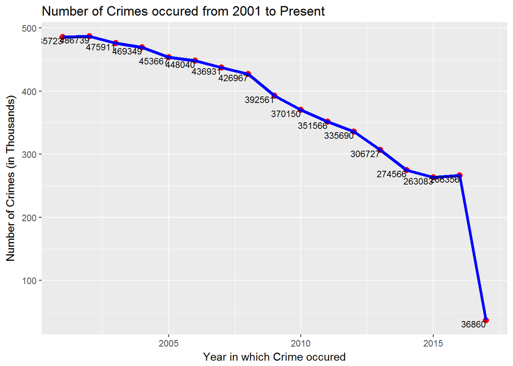

```r
Id_count <- crimedf %>%
  group_by(Year) %>%
  dplyr :: summarize(count = n())

p <- plot_ly(labels = ~Id_count$Year, Values = ~Id_count$count)

ggplot(Id_count, aes(x=Year,  y=  count/1000, label = count) )+geom_point(size = 2.5,color = "red")+geom_line(size=1.5,color= "blue") + xlab ( "Year in which Crime occured")+ ylab ("Number of Crimes (in Thousands)")+ggtitle ("Number of Crimes occured from 2001 to Present") +geom_text(size=3, hjust = 1, vjust = 1)
```

## Interpretation on Graph 1

# Graph 2. - Interactive Donut Chart to describe Percentage of different types of crime

```r
 crimedf %>%
  group_by(Primary.Type) %>%
  dplyr :: summarize(count = n()) %>%
  plot_ly(labels = ~Primary.Type, values = ~count) %>%
  add_pie(hole = 0.7) %>%
  layout(  showlegend = T,
         xaxis = list(showgrid = FALSE, zeroline = FALSE, showticklabels = FALSE),
         yaxis = list(showgrid = FALSE, zeroline = FALSE, showticklabels = FALSE))
```

[interactive chart not shown]

## Interpretation on Graph 2

# Graph 3. - Crime Rate in Chicago on Map

```r
library(ggmap)
chicago <- get_map(location = 'chicago', zoom = 11)
```

[figure not shown]

```r
map.chicago <- ggmap(chicago)
map.chicago +
  geom_point(data=crimedf, aes(x=crimedf$Longitude, y=crimedf$Latitude), color="orange", alpha=.03, size=1.1)
```

# Interpretation of Graph 3 This map graph shows areas where crimes have occured. Crime can be any of these “THEFT” “BATTERY”  
“ROBBERY” “CRIMINAL DAMAGE”  
“DECEPTIVE PRACTICE” “NARCOTICS”  
“ASSAULT” “OTHER OFFENSE”  
“CRIMINAL TRESPASS” “GAMBLING”  
“ARSON” “BURGLARY”  
“PROSTITUTION” “MOTOR VEHICLE THEFT”  
“WEAPONS VIOLATION” “HOMICIDE”  
“OFFENSE INVOLVING CHILDREN” “CRIM SEXUAL ASSAULT”  
“SEX OFFENSE” “LIQUOR LAW VIOLATION”  
“INTERFERENCE WITH PUBLIC OFFICER” “KIDNAPPING”  
“PUBLIC PEACE VIOLATION” “INTIMIDATION”  
“STALKING” “PUBLIC INDECENCY”  
“RITUALISM” “OTHER NARCOTIC VIOLATION”  
“OBSCENITY” “NON-CRIMINAL”  
“CONCEALED CARRY LICENSE VIOLATION” “HUMAN TRAFFICKING”  
“NON-CRIMINAL (SUBJECT SPECIFIED)” “NON - CRIMINAL”  
“DOMESTIC VIOLENCE”